# R 실습 자료 4차

## Cox Proportional Hazard Model

Kaplan-Meier와 Log-Rank Test 방법은 시간(Time)과 사건(Event)만을 고려하여 생존율을 추정하는 가장 단순한 방법이다.

Cox Proportional Hazard Model(이하 Cox 모형)은 사건 발생에 영향을 줄 수 있는 변수들의 특징을 반영한 모델을 구축할 수 있다. 비례위험은 시간에 상관없이 어떤 변수의 위험비(hazard ratio, HR)는 항상 일정하다는 모형의 기본가정이다(비례위험가정). 위험비는 연구기간 내 일정하기 유지되어야 한다는 가정이다.

```r
cox_fit <- coxph(Surv(futime, status==1) ~ trt
                 , data = retinopathy)
```

```r
summary(cox_fit)
```

```
Call:
coxph(formula = Surv(futime, status == 1) ~ trt, data = retinopathy)

  n= 394, number of events= 155

       coef exp(coef) se(coef)      z Pr(>|z|)
trt -0.7766    0.4600   0.1688 -4.602 4.19e-06 ***
---
Signif. codes:  0 ‘***’ 0.001 ‘**’ 0.01 ‘*’ 0.05 ‘.’ 0.1 ‘ ’ 1

    exp(coef) exp(-coef) lower .95 upper .95
trt      0.46      2.174    0.3304    0.6403

Concordance= 0.59  (se = 0.02 )
Likelihood ratio test= 22.37  on 1 df,   p=2e-06
Wald test            = 21.17  on 1 df,   p=4e-06
Score (logrank) test = 22.25  on 1 df,   p=2e-06
```

분석 결과를 시각화한다.

```r
cox_plt <- ggforest(cox_fit, data=retinopathy)
```

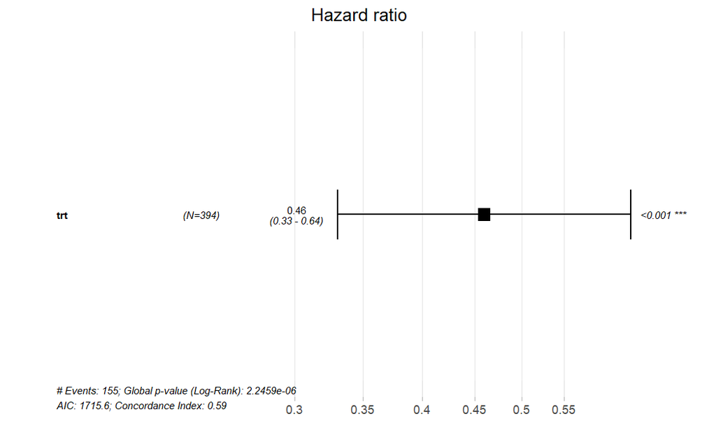

```r
plot(cox_plt)
```

`moonbook` 패키지으 `HRplot()` 이용해서 시각화 할 수 있다.

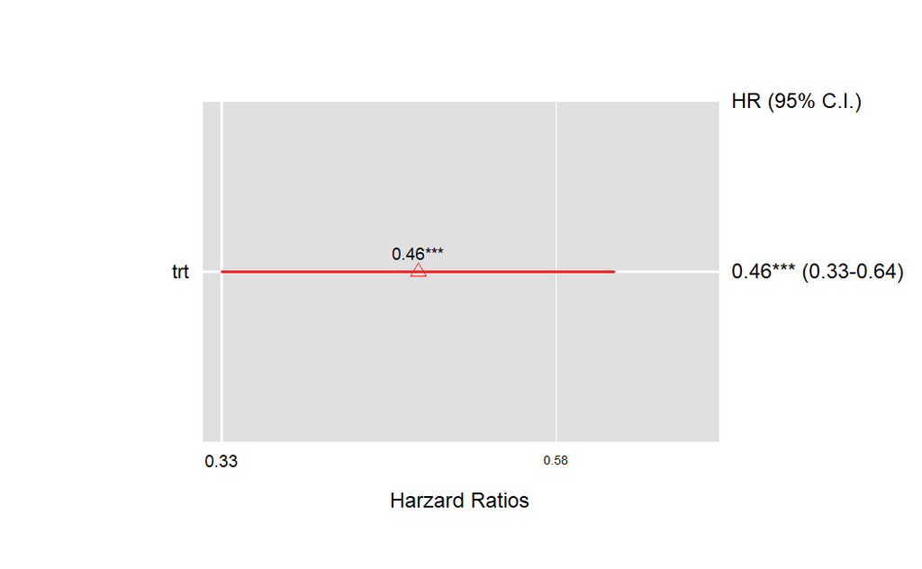

```r
HRplot(cox_fit,show.CI=TRUE,pch=2,sig=0.05)
```

### finalfit

단순 분석과 다중 분석을 `finalfit` 패키지를 이용해서 간단히 수행할 수 있다.

```r
library(finalfit)
dependent_model <- 'Surv(futime, status == 1)'
explanatory <- c('trt', 'age', 'laser', 'type', 'risk')

result_cox <- retinopathy %>%
  finalfit(dependent_model, explanatory, add_dependent_label = FALSE)
```

```r
print(result_cox)
```

```
 label    levels         all          HR (univariable)        HR (multivariable)
   trt         0  197 (50.0)                         -                         -
               1  197 (50.0) 0.46 (0.33-0.64, p<0.001) 0.45 (0.33-0.63, p<0.001)
   age Mean (SD) 20.8 (14.8) 1.00 (0.99-1.01, p=0.604) 1.01 (0.99-1.03, p=0.323)
 laser     xenon  200 (50.8)                         -                         -
           argon  194 (49.2) 1.17 (0.86-1.61, p=0.316) 1.21 (0.88-1.66, p=0.244)
  type  juvenile  228 (57.9)                         -                         -
           adult  166 (42.1) 1.02 (0.74-1.40, p=0.894) 0.86 (0.48-1.52, p=0.598)
  risk Mean (SD)   9.7 (1.5) 1.16 (1.04-1.29, p=0.009) 1.16 (1.04-1.29, p=0.008)
```

```r
print(ztable(result_cox), type='viewer')
```

[output not shown]